# Data Wrangling and Cleaning: Steps 1-11

David Mullaly

2026-02-23

## Introduction

This document covers the data wrangling process and all eleven data cleaning steps for the problem. We load multiple relational tables, merge them into a single flat file, and perform comprehensive data cleaning to prepare for missing data analysis.

### Data Cleaning Steps Covered:

**Steps 1-5 (Initial Cleaning)**

1. Open data in your software of choice
2. Review variables for common sense based on SME knowledge
3. Review how the software coded the variables (nominal, continuous)
4. Perform data integrity/validation checks
5. Handle dates

**Steps 6-7 (Categorical & Zero-Variance)**

6. Handle categorical variables - keep as is, combine rare levels, combine similar levels
7. Handle zero-variance predictors

**Steps 8-11 (Advanced Cleaning)**

8. Handle near zero-variance predictors
9. Eliminate redundant columns and linear combination columns
10. Search for outliers and initial search for missing values
11. Sanity check using Decision Tree (1 to 2 splits)

## Data Loading and Wrangling

Load four relational tables and merge into a single flat file (FFdf) using left joins on Cust_ID.

```
## MainDF: 9447 48 | StoreDF: 9272 3 | ConcessDF: 9272 3 | CustomerDF: 14272 7
```

```
## Duplicates in MainDF: 175
```

```
## Duplicates in StoreDF: 0
```

```
## Duplicates in ConcessDF: 0
```

```
## Duplicates in CustomerDF: 0
```

```
## Final flat file dimensions - Rows: 9447 Columns: 58
```

```
## Unique Cust_ID: 9272 | Duplicate rows: 175
```

## Step 1: Open Data in Your Software of Choice

Create identifier variable, arrange columns, and explore distributions visually.

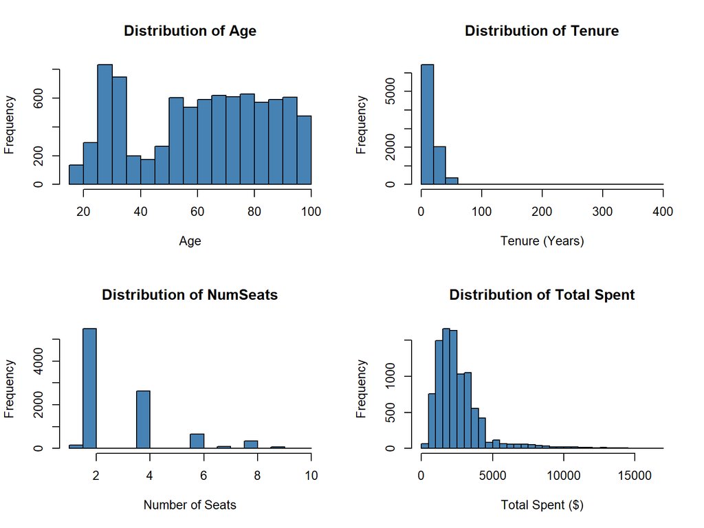

```
## Response Variable (Y01): 2196 7251
```

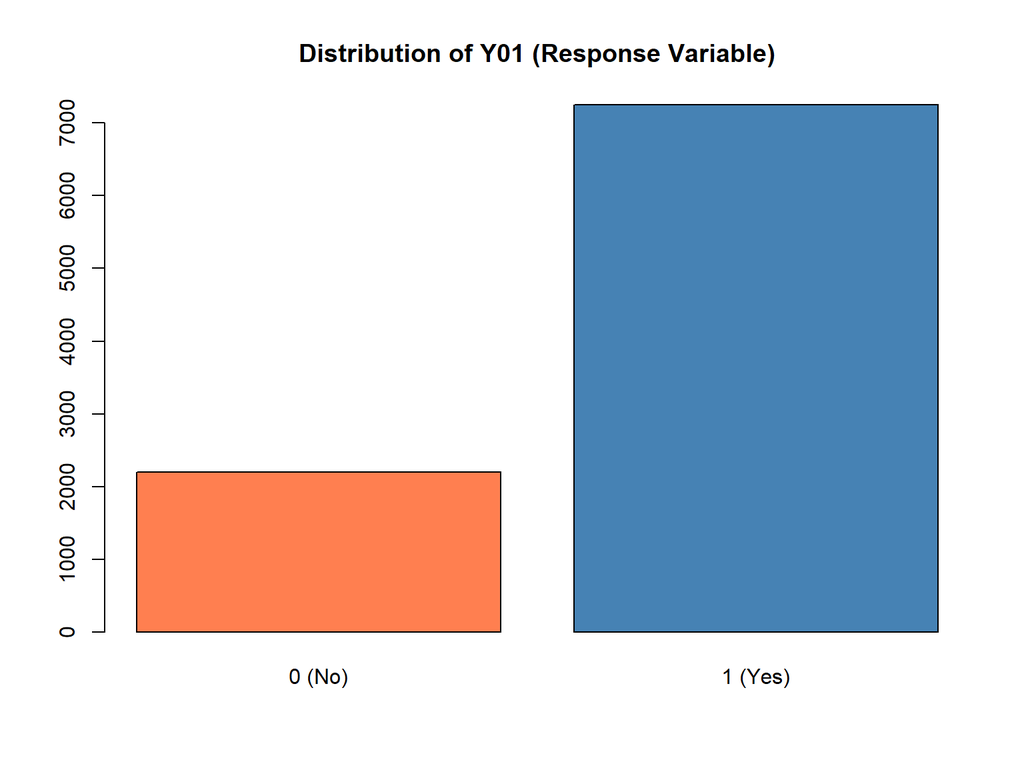

## Step 2: Review Variables for Common Sense (SME Knowledge)

Standardize variable names and check for unique identifiers.

```
## Dataset: 9447 rows, 59 columns
```

```
## Unique Cust_ID: 9272 out of 9447 rows
```

**Result:** Each row does not necessarily represent a unique customer (175 duplicate Cust_IDs found in MainDF source data).

## Step 3: Review How Software Coded Variables

Convert character variables to factors for proper categorical analysis.

```
## Character variables to convert: 23
```

```
##
## Sex levels: F M
```

```
## Marital levels: D M S U
```

```
## Account_Type levels: Business Personal Shared
```

**Note:** Marital has levels D (Divorced), M (Married), S (Single), U (Unknown). The “U” for Unknown may need special handling.

## Step 4: Data Integrity/Validation Checks

Check for anomalies, bogus values, and data quality issues.

```
## Age range: 18 99
```

```
## Tenure range: 1 400
```

```
## NumSeats range: 1 10
```

```
##
## DistA values = 999: 1506
```

```
## DistA NA count after conversion: 2895
```

```
##
## Survey_Comp range: 0 7.4
```

```
## Survey_Comp values > 1: 110
```

```
##
## State_Name unique: 50 | State_Loc unique: 50
```

**Issues Found:**

- **DistA = 999:** Placeholder values converted to NA
- **Survey_Comp > 1:** Outlier found when expected range is 0-1
- **Age max = 99:** May be placeholder or extreme value - verify with SME
- **Tenure max = 400:** Suspicious value if measured in years - verify units with SME
- **State_Name/State_Loc:** Redundant columns (same info, different format)
- **Marital = “U”:** Unknown status - consider treating as NA
- **Cust_ID duplicates:** 175 duplicate IDs found in MainDF source data
- **Address, Name, PhoneNum:** 100% missing - likely removed from CustomerDF for privacy

## Step 5: Handle Dates

Convert Last_Contact datetime and extract useful components.

```
## Date components extracted: Contact_Year, Contact_Month, Contact_Day, Contact_Weekday, Contact_Hour
```

```
## Contact Year range: 2018 2025
```

```
## Contact Hour range: 0 23
```

## Summary

```
## Final Dataset: 9447 rows x 64 columns
```

```
## Total Missing Values: 94591
```

```
##
## Columns with missing values:
```

```
##               Address                  Name              PhoneNum
##                  9447                  9447                  9447
##     Educational_Level  Favorite_Caps_Player        Favorite_Sport
##                  6612                  6612                  6612
##            Job_Sector     Mode_Of_Transport            Team_B_STH
##                  6612                  6612                  6612
##            Team_C_STH        Net_Worth_True HouseHold_Income_True
##                  6612                  5762                  5691
##                 DistA               Marital                   Age
##                  2895                  1155                   986
##              Rep_Name                   Sex                Tenure
##                   871                   667                   592
##            Rep_Visits             Rep_Calls          Num_Children
##                   508                   433                   406
```

### Data Quality Issues for Future Steps:

| Issue | Possible action / Action Taken |
| --- | --- |
| DistA = 999 | Converted to NA |
| Survey_Comp > 1 | Flag for investigation (110 values, max 7.4) |
| Age = 99 | Verify with SME |
| Tenure = 400 | Verify units with SME (400 years unlikely) |
| Marital = “U” | Consider as NA or keep |
| State redundancy | Drop one column |
| ID columns | Exclude from modeling |
| Cust_ID duplicates | 175 duplicates in MainDF - investigate or deduplicate |
| PII columns | Address, Name, PhoneNum 100% missing - exclude |

**Step 6: Handle Categorical Variables - keep as is, combine rare levels, combine similar levels**

```
## Factor variables: 23
```

```
##
## Variables with rare levels (< 5%):
```

```
##  [1] "Educational_Level"     "Favorite_Caps_Player"  "Favorite_Sport"
##  [4] "Favorite_Team"         "Job_Sector"            "Marital"
##  [7] "Mode_Of_Transport"     "Most_Purch_Concession" "Mult_Loc"
## [10] "Rep_Name"              "Seating_Location"      "State_Loc"
## [13] "State_Name"
```

```
##
## --- Sex Distribution ---
```

```
##
##    F    M <NA>
## 1078 7702  667
```

```
##
## --- Marital Distribution ---
```

```
##
##    D    M    S    U <NA>
##  908 6227  909  248 1155
```

```
##
## --- Account_Type Distribution ---
```

```
##
## Business Personal   Shared
##     1057     7462      928
```

```
##
## --- Educational_Level Distribution ---
```

```
##
##   AD   BD   HS   MD  PHD   SC <NA>
##  450  827  547  313  237  461 6612
```

```
## Marital 'U' (Unknown) count: 248
```

```
## Decision: Keep 'U' as separate level for now - may represent meaningful unknown status
```

```
##
## --- State_Name levels ---
```

```
## [1] 50
```

```
## Number of unique states: 50
```

```
## === LUMPING RARE LEVELS (< 5%) INTO 'Other' ===
```

```
## Favorite_Sport: 8 -> 2 levels
##
##   NHL Other  <NA>
##  1996   839  6612
##
## Favorite_Team: 25 -> 4 levels
##
##   New Jersey Devils Philadelphia Flyers Washington Capitals               Other
##                 788                 856                6632                1171
##
## Mode_Of_Transport: 5 -> 4 levels
##
##       Car    Public Uber/Taxi     Other      <NA>
##      1104       905       603       223      6612
##
## Most_Purch_Concession: 9 -> 8 levels
##
##      Beer    Burger   Hot Dog   Peanuts   Popcorn      Soda Specialty     Other
##      2294       955      1422       474      1387      1425       977       513
##
## Rep_Name: 9 -> 7 levels
##
## Alice David  Emma Frank Grace   Ivy Other  <NA>
##   823  1798  1538  1942   952   959   564   871
```

```
## Lumping complete.
```

```
## --- Region Distribution (grouped from State_Name) ---
```

```
##
##    DCArea   Midwest Northeast     South      West
##      4842       551      1703      1856       495
```

```
##
## Region percentages:
```

```
##
##    DCArea   Midwest Northeast     South      West
##     51.25      5.83     18.03     19.65      5.24
```

```
##
## All states successfully mapped to regions.
```

**Step 6 Observations:**

- Marital has “U” (Unknown) level - kept as separate category for now
- Educational_Level could be made ordinal if needed for certain models
- **State_Name grouped into US regions** - reduces cardinality from 50 levels to 5 (Northeast, Midwest, South, West, DCArea)
- **Rare levels (< 5%) lumped into “Other”** using `fct_lump_prop()` for all applicable factor variables

**Step 7: Remove Zero-Variance Predictors**

```
## Zero-variance columns found: 8
```

```
## Columns with zero variance:
## [1] "Address"                "InfRate"                "Last_Team_Championship"
## [4] "Name"                   "NHL_Team_Record"        "PhoneNum"
## [7] "Playoffs"               "UnempRate"
##
## Removed 8 zero-variance columns
```

```
## Remaining columns: 58
```

**Step 7 Results:**

The following 8 zero-variance columns were identified and removed:

- **Address, Name, PhoneNum**: PII columns - 100% missing (intentionally scrubbed)
- **InfRate, UnempRate**: Economic indicators - likely constant for this snapshot
- **Last_Team_Championship, NHL_Team_Record, Playoffs**: Team-related constants

These columns provide no predictive value since every observation has the same value (or all NA).

## Class 4: Data Cleaning Process: Steps 8-11

**Step 8: Handle Near Zero-Variance Predictors**

```
## Near-zero variance columns (>95% one value):
```

```
##           Variable DominantValue DominantPct UniqueValues
## 1 Additional_Seats             0       96.99           12
## 2         Mult_Loc            No       96.99            2
```

```
## Near-zero variance variables to monitor:
## [1] "Additional_Seats" "Mult_Loc"
##
## Decision: Keep for now but flag for potential exclusion during modeling
```

**Step 8 Results:**

Near-zero variance columns identified (>95% one value):

| Variable | Dominant Value | Dominant % |
| --- | --- | --- |
| Additional_Seats | 0 | 96.99% |
| Mult_Loc | No | 96.99% |

**Observations:**

- **Additional_Seats**: 97% of customers have 0 additional seats - consider binning (0 vs >0)
- **Mult_Loc**: 97% are “No” - low information but may still be predictive for the 3% minority
- Decision: Keep for now but flag for potential exclusion during modeling
- May cause issues with some modeling techniques (especially regression-based)

**Step 9: Remove Redundant Columns and Linear Combination Columns**

```
## --- Checking State_Name vs State_Loc redundancy ---
```

```
## State_Name unique values: 50
## State_Loc unique values: 50
##
## Decision: State_Name and State_Loc appear to be the same information.
## Removing State_Loc (keeping State_Name)
```

```
##
## --- Highly correlated variable pairs (|r| > 0.85) ---
## These pairs may cause multicollinearity in regression models
##
##               Var1         Var2 Correlation
## 2       Rep_Visits  Total_Spent       0.947
## 4 Weekday_Attended Weekday_Sold      -0.946
## 1 Concession_Total     NumSeats       0.915
## 3 Team_Store_Total  Total_Spent       0.853
```

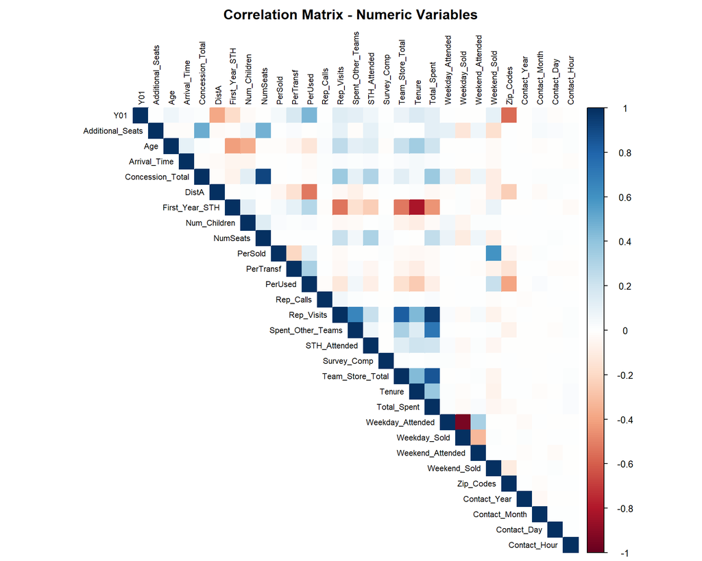

```
## === MULTICOLLINEARITY ANALYSIS ===
```

```
## Cluster 1: Spending & Visit variables
```

```
##   - Rep_Visits <-> Total_Spent: r = 0.947 (very strong positive)
```

```
##   - Team_Store_Total <-> Total_Spent: r = 0.853 (strong positive)
```

```
##   Recommendation: Consider removing Rep_Visits or Total_Spent
```

```
## Cluster 2: Concession & Seating
```

```
##   - Concession_Total <-> NumSeats: r = 0.915 (strong positive)
```

```
##   Recommendation: Makes business sense - more seats = more concessions
```

```
## Cluster 3: Attendance pairs
```

```
##   - Weekday_Attended <-> Weekday_Sold: r = -0.946 (strong NEGATIVE)
```

```
##   Note: Negative correlation suggests inverse relationship
```

```
##   Recommendation: Keep both - they capture different behaviors
```

```
## Variables flagged for potential removal due to multicollinearity:
```

```
## [1] "Rep_Visits"       "Team_Store_Total"
```

```
##
## Decision: Flag but keep for now; remove during modeling if VIF > 10
```

**Step 9 Observations:**

Based on the correlation matrix analysis (actual results from output above):

| Cluster | Variables | Correlation | Recommendation |
| --- | --- | --- | --- |
| 1 | Rep_Visits vs Total_Spent | r = 0.947 | Remove Rep_Visits |
| 1 | Team_Store_Total vs Total_Spent | r = 0.853 | Monitor for VIF |
| 2 | Concession_Total vs NumSeats | r = 0.915 | Keep - business logic |
| 3 | Weekday_Attended vs Weekday_Sold | r = -0.946 | Keep both - inverse relationship |
| - | State_Loc vs State_Name | Redundant | **REMOVED** |

**Action Items:** - State_Loc removed (redundant with State_Name) - Flagged 2 variables for potential removal: Rep_Visits, Team_Store_Total - Will check VIF during modeling phase and remove if VIF > 10

**Step 10: Search for Outliers and Initial Search for Missing Values**

```
## Age outliers (IQR method): 0 values
```

```
## Tenure outliers: 8 values | Max: 400
```

```
## Survey_Comp values > 1: 110
```

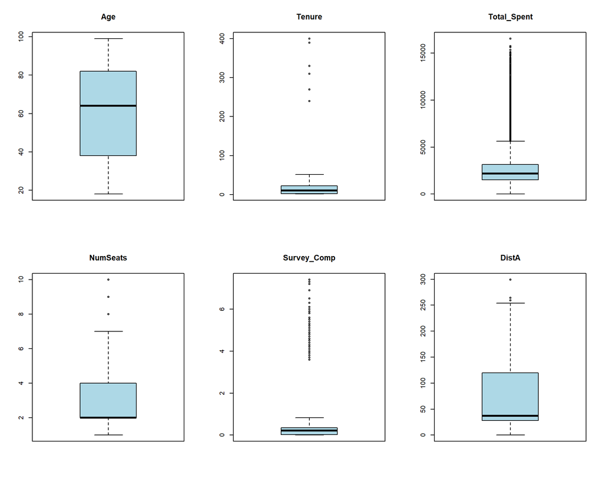

```
## === MISSING DATA ASSESSMENT ===
```

```
## Total missing values: 67405 out of 538479 ( 12.52 %)
```

```
## Columns with missing values:
```

```
##                 Variable Missing_Count Missing_Pct
## 1      Educational_Level          6612       69.99
## 2   Favorite_Caps_Player          6612       69.99
## 3         Favorite_Sport          6612       69.99
## 4             Job_Sector          6612       69.99
## 5      Mode_Of_Transport          6612       69.99
## 6             Team_B_STH          6612       69.99
## 7             Team_C_STH          6612       69.99
## 8         Net_Worth_True          5762       60.99
## 9  HouseHold_Income_True          5691       60.24
## 10                 DistA          2895       30.64
## 11               Marital          1155       12.23
## 12      Marital_Original          1155       12.23
## 13                   Age           986       10.44
## 14              Rep_Name           871        9.22
## 15                   Sex           667        7.06
## 16                Tenure           592        6.27
## 17            Rep_Visits           508        5.38
## 18             Rep_Calls           433        4.58
## 19          Num_Children           406        4.30
```

```
##
## === OUTLIER DECISIONS ===
```

```
## 1. Tenure max = 400:
```

```
##    - If measured in years, this is impossible
```

```
##    - May be measured in months (400 months = 33 years - plausible)
```

```
##    - ACTION: Verify units with SME; flag for review
```

```
## 2. Age = 99:
```

```
##    - Could be real (elderly customer) or placeholder
```

```
##    - ACTION: Verify with SME; consider if 99 is data entry default
```

```
## 3. Survey_Comp values > 1 (expected 0-1 range):
```

```
##    - Count: 110
```

```
##    - Max value: 7.4
```

```
##    - ACTION: Possible scale issue; cap at 1 or investigate data source
```

```
## Created outlier flag variables: Flag_Tenure_High, Flag_Survey_Invalid
```

**Step 11: Sanity Check Using Decision Tree (1 to 2 splits)**

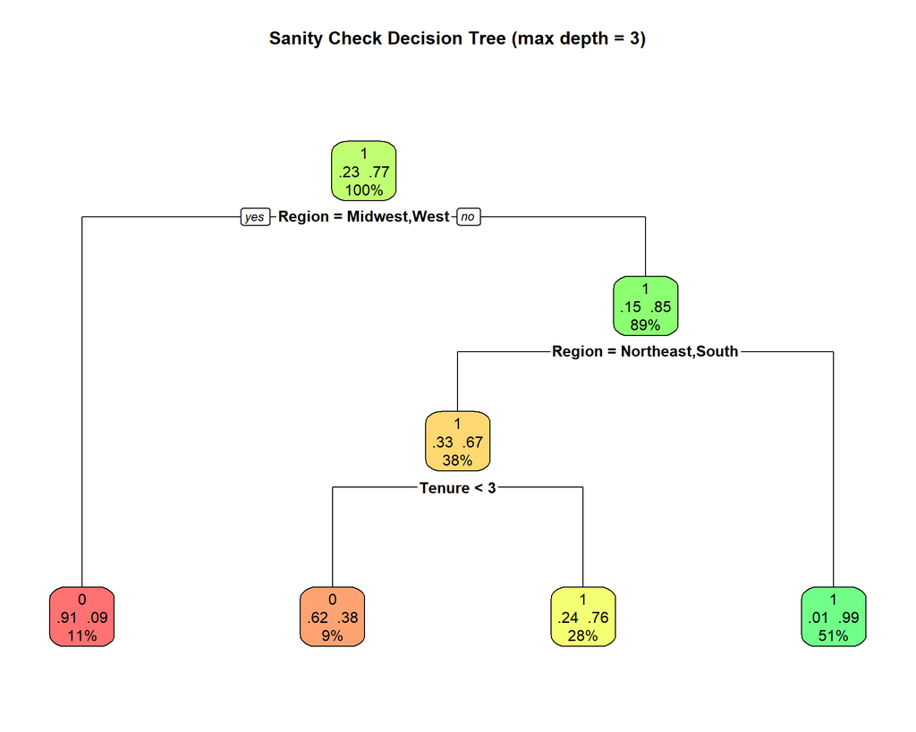

```
##
## === VARIABLE IMPORTANCE ===
```

```
##           Region    Favorite_Team          PerUsed            DistA
##       1505.21434        253.50828        245.18919        196.77674
##           Tenure   First_Year_STH         Rep_Name     Rejoined_STH
##        187.73632        125.59980         80.93227         50.19569
## Team_Store_Total        PerTransf
##         26.31404         21.05856
```

```
##
## === SANITY CHECK ANALYSIS ===
```

```
## Tree accuracy: 88.11 %
```

```
## Accuracy is reasonable - no obvious data leakage detected
```

**Step 11 Results:**

The decision tree uses Region (from Step 6) instead of raw State_Name/Zip_Codes to avoid overfitting from high-cardinality variables.

Top Variable Importance:

| Variable | Importance |
| --- | --- |
| Region | 1505.2 |
| Favorite_Team | 253.5 |
| PerUsed | 245.2 |
| DistA | 196.8 |
| Tenure | 187.7 |

**Analysis:**

- **Accuracy ~88%** - reasonable, no obvious data leakage
- **Region is the dominant predictor** - geographic location strongly predicts Y01
- **No high-cardinality variables** causing artificial inflation of accuracy

## Summary of Steps 6-11 (Data Cleaning Complete)

```
## === DATA CLEANING SUMMARY (Steps 6-11) ===
```

```
## Step 6 - Handle Categorical Variables:
```

```
##   - Rare factor levels (< 5%) lumped into 'Other' via fct_lump_prop()
```

```
##   - Marital 'U' kept as separate category
```

```
##   - State_Name grouped into US Census regions
```

```
## Step 7 - Zero-Variance Predictors:
```

```
##   - Columns removed: 8
```

```
## Step 8 - Near Zero-Variance Predictors:
```

```
##   - Variables flagged: 2
```

```
##   - Decision: Keep for now but monitor during modeling
```

```
## Step 9 - Redundant Columns:
```

```
##   - State_Loc removed (redundant with State_Name)
```

```
##   - Correlation matrix reviewed for multicollinearity
```

```
## Step 10 - Outliers & Missing Data:
```

```
##   - Total missing values: 67997
```

```
##   - Outlier flags created for Tenure and Survey_Comp
```

```
##   - Missing data summary table generated
```

```
## Step 11 - Decision Tree Sanity Check:
```

```
##   - Tree accuracy: 88.11 %
```

```
##   - Review variable importance for potential data leakage
```

```
## Final dataset dimensions: 9447 rows x 59 columns
```

```
##
## Cleaned dataset saved to: FFdf_cleaned.csv
```

### Issues Identified for Further Action:

| Step | Issue | Recommendation |
| --- | --- | --- |
| 6 | Marital “U” unknown | Keep as category or convert to NA during imputation |
| 6 | Rare factor levels (< 5%) | **RESOLVED:** Lumped into “Other” via fct_lump_prop() |
| 6 | State_Name high cardinality | **RESOLVED:** Grouped into US Census regions |
| 7 | Zero-variance columns | Removed from dataset |
| 8 | Near-zero variance | Monitor during modeling; consider binning |
| 9 | State_Loc redundant | Removed |
| 10 | Tenure = 400 | Verify units with SME (years vs months?) |
| 10 | Survey_Comp > 1 | Investigate scale/cap values at 1 |
| 10 | Missing data patterns | Address in Missing Data phase (Class 5+) |
| 11 | Tree predictors | **RESOLVED:** Using Region variable instead of State_Name |

## Missing Data Analysis: Steps 1-6

### MD Step 1: Identify Missing Data

Rename to MDdf and count all missing values by variable.

```r
MDdf <- FFdf

missing_summary <- data.frame(
  Variable     = names(MDdf),
  Missing_Count = colSums(is.na(MDdf)),
  Missing_Pct  = round(colSums(is.na(MDdf)) / nrow(MDdf) * 100, 1)
) %>% filter(Missing_Count > 0) %>% arrange(desc(Missing_Count))

cat("Total missing:", sum(is.na(MDdf)), "of", nrow(MDdf)*ncol(MDdf), "cells (",
    round(sum(is.na(MDdf))/(nrow(MDdf)*ncol(MDdf))*100,1), "%)\n")
```

```
## Total missing: 67997 of 557373 cells ( 12.2 %)
```

```r
flextable(missing_summary) %>%
  set_header_labels(Variable="Variable", Missing_Count="Missing (n)", Missing_Pct="Missing (%)") %>%
  autofit()
```

| Variable | Missing (n) | Missing (%) |
| --- | --- | --- |
| Educational_Level | 6,612 | 70.0 |
| Favorite_Caps_Player | 6,612 | 70.0 |
| Favorite_Sport | 6,612 | 70.0 |
| Job_Sector | 6,612 | 70.0 |
| Mode_Of_Transport | 6,612 | 70.0 |
| Team_B_STH | 6,612 | 70.0 |
| Team_C_STH | 6,612 | 70.0 |
| Net_Worth_True | 5,762 | 61.0 |
| HouseHold_Income_True | 5,691 | 60.2 |
| DistA | 2,895 | 30.6 |
| Marital | 1,155 | 12.2 |
| Marital_Original | 1,155 | 12.2 |
| Age | 986 | 10.4 |
| Rep_Name | 871 | 9.2 |
| Sex | 667 | 7.1 |
| Tenure | 592 | 6.3 |
| Flag_Tenure_High | 592 | 6.3 |
| Rep_Visits | 508 | 5.4 |
| Rep_Calls | 433 | 4.6 |
| Num_Children | 406 | 4.3 |

**Observations:**

### MD Step 2: Mark Missing Data

Create binary indicator variables (M_VarName: 1 = missing, 0 = present) for all variables with NAs. Indicators allow MCAR/MAR testing and preserve pre-imputation missingness structure.

```r
vars_with_na <- names(MDdf)[colSums(is.na(MDdf)) > 0]
vars_with_na <- vars_with_na[!vars_with_na %in% c("Marital_Original", "Flag_Tenure_High")]

for(var in vars_with_na) {
  MDdf[[paste0("M_", var)]] <- ifelse(is.na(MDdf[[var]]), 1, 0)
}

indicator_vars <- grep("^M_", names(MDdf), value = TRUE)
cat("Indicator variables created:", length(indicator_vars), "\n")
```

```
## Indicator variables created: 18
```

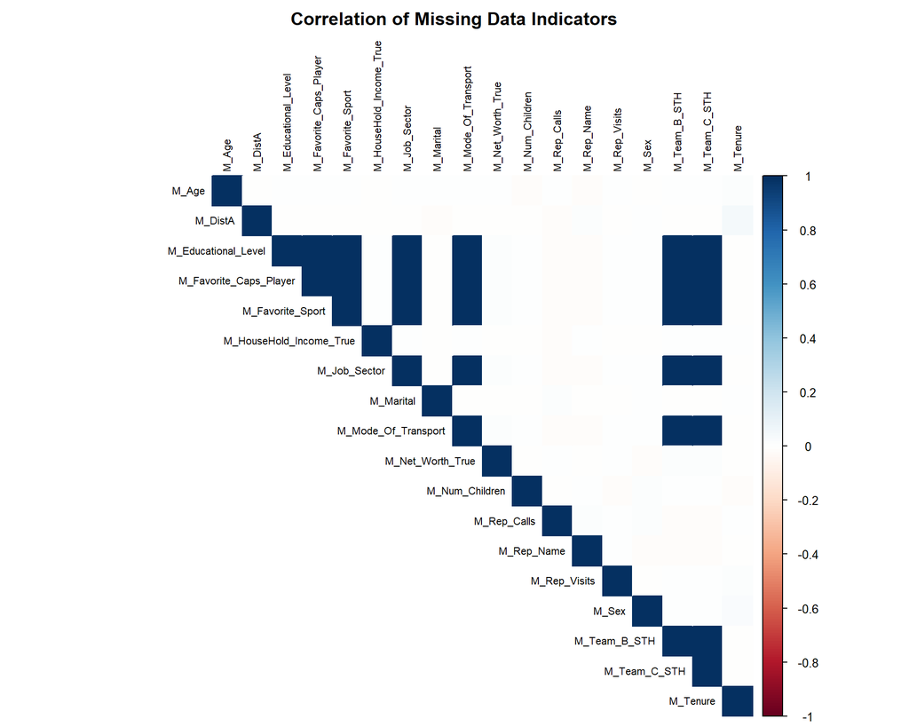

```r
# Correlation of indicators — high r = missing as a block
indicator_matrix <- MDdf[, indicator_vars]
indicator_matrix <- indicator_matrix[, sapply(indicator_matrix, stats::var) > 0]
cor_indicators <- cor(indicator_matrix)

corrplot(cor_indicators, method = "color", type = "upper",
         tl.cex = 0.7, tl.col = "black",
         title = "Correlation of Missing Data Indicators",
         mar = c(0, 0, 2, 0))
```

### MD Step 3: Clean Up Obvious Mistakes

Fix values that are wrong or that should be coded as NA.

```r
# Survey_Comp > 1: cap at 1.0 (proportion cannot exceed 100%)
cat("Survey_Comp > 1 count:", sum(MDdf$Survey_Comp > 1, na.rm = TRUE), "| max:", max(MDdf$Survey_Comp, na.rm = TRUE), "\n")
```

```
## Survey_Comp > 1 count: 110 | max: 7.4
```

```r
MDdf$Survey_Comp[MDdf$Survey_Comp > 1] <- 1.0
cat("Survey_Comp after cap:", range(MDdf$Survey_Comp, na.rm = TRUE), "\n\n")
```

```
## Survey_Comp after cap: 0 1
```

```r
# Marital "U": keep as valid level — unknown status is informative
cat("Marital 'U' count:", sum(MDdf$Marital == "U", na.rm = TRUE), "— KEPT as distinct level\n")
```

```
## Marital 'U' count: 248 — KEPT as distinct level
```

```r
cat("Marital true NAs:", sum(is.na(MDdf$Marital)), "\n\n")
```

```
## Marital true NAs: 1155
```

```r
# Tenure / Age extremes: flag only, leave for SME
cat("Tenure > 100:", sum(MDdf$Tenure > 100, na.rm = TRUE), "| Age == 99:", sum(MDdf$Age == 99, na.rm = TRUE), "— flagged, left as-is\n")
```

```
## Tenure > 100: 8 | Age == 99: 111 — flagged, left as-is
```

```r
cat("Total missing after cleanup:", sum(is.na(MDdf)), "\n")
```

```
## Total missing after cleanup: 67997
```

**Observations:**

- Survey_Comp: 110 values capped at 1.0 (data entry errors on a 0–1 proportion scale).
- Marital “U” (248 values): kept — preserves information, lets model treat “Unknown” as its own category. True NAs still go to MICE.
- Tenure = 400 / Age = 99: left pending SME confirmation of units.

### MD Step 4: Make Easy Decisions on Rows/Columns

Define which columns are excluded from imputation (non-analytical only). No rows excluded. All variables with missing data — including the 70% block — are imputed.

```r
id_cols       <- c("ID", "Cust_ID")
backup_cols   <- c("Marital_Original", "Flag_Tenure_High", "Flag_Survey_Invalid")
date_cols     <- c("Last_Contact","Contact_Year","Contact_Month","Contact_Day","Contact_Weekday","Contact_Hour")
high_card_cols <- c("State_Name", "Zip_Codes", "Seating_Location")
indicator_cols <- grep("^M_", names(MDdf), value = TRUE)

all_exclude <- c(id_cols, backup_cols, date_cols, high_card_cols, indicator_cols)
impute_vars  <- names(MDdf)[!names(MDdf) %in% all_exclude]
impute_with_na <- impute_vars[colSums(is.na(MDdf[, impute_vars])) > 0]

cat("Columns excluded from imputation:", length(all_exclude), "\n")
```

```
## Columns excluded from imputation: 32
```

```r
cat("Imputation-eligible variables:", length(impute_vars), "| with NAs:", length(impute_with_na), "\n\n")
```

```
## Imputation-eligible variables: 45 | with NAs: 18
```

```r
# Row missing summary
row_na <- rowSums(is.na(MDdf[, impute_vars]))
cat("Row NA distribution among eligible columns:\n")
```

```
## Row NA distribution among eligible columns:
```

```r
cat("  0 missing:", sum(row_na == 0), "| 1-3:", sum(row_na >= 1 & row_na <= 3),
    "| 4-6:", sum(row_na >= 4 & row_na <= 6), "| 7+:", sum(row_na > 6), "\n")
```

```
##   0 missing: 168 | 1-3: 2370 | 4-6: 296 | 7+: 6613
```

```r
cat("Decision: No rows excluded.\n")
```

```
## Decision: No rows excluded.
```

**Observations:**

- Excluded: ID/Cust_ID, derived backup/flag columns, date components, high-cardinality cols (State_Name, Zip_Codes, Seating_Location), all M_ indicators.
- All variables with missing data are kept for imputation — including the 70% block — to observe the full effect on modeling.

### MD Step 5: Assess Missingness Patterns (MCAR vs MAR)

Use decision trees predicting each variable’s M_ indicator. If the tree finds splits, missingness is predictable from other data → MAR. No splits → likely MCAR.

```r
predictor_candidates <- impute_vars[colSums(is.na(MDdf[, impute_vars])) == 0]
complete_predictors  <- MDdf[, predictor_candidates]

# Drop high-cardinality factors and logical columns
complete_predictors <- complete_predictors[, sapply(complete_predictors, function(x)
  !(is.factor(x) && nlevels(x) > 30))]
complete_predictors <- as.data.frame(lapply(complete_predictors, function(x)
  if(is.logical(x)) as.integer(x) else x))

results <- data.frame(Variable=character(), Splits=integer(), Accuracy=numeric(),
                      Top_Predictor=character(), Assessment=character(), stringsAsFactors=FALSE)

for(var in impute_with_na) {
  target <- factor(MDdf[[paste0("M_", var)]], levels=c(0,1), labels=c("Present","Missing"))
  tree_data <- cbind(Target=target, complete_predictors)
  tree_model <- rpart(Target ~ ., data=tree_data, method="class",
                      control=rpart.control(maxdepth=3, minsplit=50, cp=0.01))

  n_splits <- nrow(tree_model$frame[tree_model$frame$var != "<leaf>", ])
  acc      <- round(mean(predict(tree_model, tree_data, type="class") == target) * 100, 1)
  top_pred <- if(length(tree_model$variable.importance) > 0) names(tree_model$variable.importance)[1] else "None"
  assessment <- if(n_splits == 0) "Likely MCAR" else if(acc > 85) "MAR" else "Possibly MAR"

  results <- rbind(results, data.frame(Variable=var, Splits=n_splits, Accuracy=acc,
                                       Top_Predictor=top_pred, Assessment=assessment,
                                       stringsAsFactors=FALSE))
}

flextable(results) %>%
  set_header_labels(Variable="Variable", Splits="Splits", Accuracy="Accuracy (%)",
                    Top_Predictor="Top Predictor", Assessment="Assessment") %>%
  color(~ Assessment == "MAR",         ~ Assessment, color="red") %>%
  color(~ Assessment == "Likely MCAR", ~ Assessment, color="darkgreen") %>%
  color(~ Assessment == "Possibly MAR",~ Assessment, color="orange") %>%
  autofit()
```

| Variable | Splits | Accuracy (%) | Top Predictor | Assessment |
| --- | --- | --- | --- | --- |
| Age | 0 | 89.6 | None | Likely MCAR |
| DistA | 5 | 86.7 | Y01 | MAR |
| Educational_Level | 0 | 70.0 | None | Likely MCAR |
| Favorite_Caps_Player | 0 | 70.0 | None | Likely MCAR |
| Favorite_Sport | 0 | 70.0 | None | Likely MCAR |
| HouseHold_Income_True | 0 | 60.2 | None | Likely MCAR |
| Job_Sector | 0 | 70.0 | None | Likely MCAR |
| Marital | 0 | 87.8 | None | Likely MCAR |
| Mode_Of_Transport | 0 | 70.0 | None | Likely MCAR |
| Net_Worth_True | 0 | 61.0 | None | Likely MCAR |
| Num_Children | 0 | 95.7 | None | Likely MCAR |
| Rep_Calls | 0 | 95.4 | None | Likely MCAR |
| Rep_Name | 0 | 90.8 | None | Likely MCAR |
| Rep_Visits | 0 | 94.6 | None | Likely MCAR |
| Sex | 0 | 92.9 | None | Likely MCAR |
| Team_B_STH | 0 | 70.0 | None | Likely MCAR |
| Team_C_STH | 0 | 70.0 | None | Likely MCAR |
| Tenure | 0 | 93.7 | None | Likely MCAR |

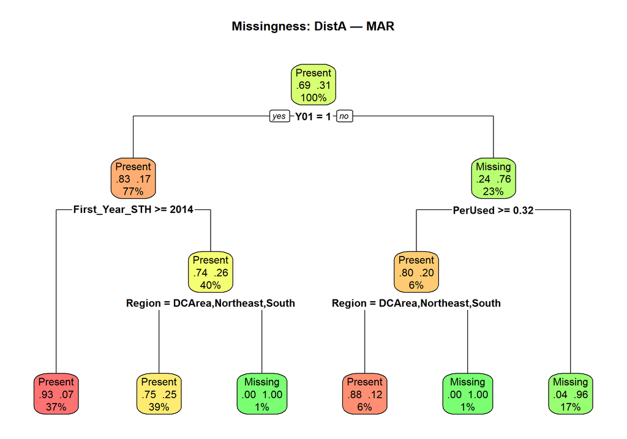

```r
vars_with_splits <- results$Variable[results$Splits > 0]
for(var in vars_with_splits[1:min(4, length(vars_with_splits))]) {
  target     <- factor(MDdf[[paste0("M_", var)]], levels=c(0,1), labels=c("Present","Missing"))
  tree_model <- rpart(Target ~ ., data=cbind(Target=target, complete_predictors), method="class",
                      control=rpart.control(maxdepth=3, minsplit=50, cp=0.01))
  rpart.plot(tree_model, main=paste("Missingness:", var, "—", results$Assessment[results$Variable==var]),
             extra=104, box.palette="RdYlGn")
}
```

### MD Step 6: Simple (Univariate) Imputation

Handle variables with small missingness using simple methods before MICE. **Management dictates** stochastic (independent) imputation for Rep_Calls and Rep_Name, and regression-based imputation for Age.

[output not shown]

```r
get_mode <- function(x) { x <- x[!is.na(x)]; ux <- unique(x); ux[which.max(tabulate(match(x, ux)))] }

# --- Median imputation ---
median_nc <- median(MDdf$Num_Children, na.rm=TRUE)
MDdf$Num_Children[is.na(MDdf$Num_Children)] <- median_nc
cat("Num_Children: imputed with median =", median_nc, "| NAs remaining:", sum(is.na(MDdf$Num_Children)), "\n")
```

```
## Num_Children: imputed with median = 1 | NAs remaining: 0
```

```r
median_rv <- median(MDdf$Rep_Visits, na.rm=TRUE)
MDdf$Rep_Visits[is.na(MDdf$Rep_Visits)] <- median_rv
cat("Rep_Visits: imputed with median =", round(median_rv,2), "| NAs remaining:", sum(is.na(MDdf$Rep_Visits)), "\n\n")
```

```
## Rep_Visits: imputed with median = 13 | NAs remaining: 0
```

```r
# --- Mode imputation ---
mode_mpc <- get_mode(MDdf$Most_Purch_Concession)
MDdf$Most_Purch_Concession[is.na(MDdf$Most_Purch_Concession)] <- mode_mpc
cat("Most_Purch_Concession: imputed with mode =", as.character(mode_mpc), "| NAs:", sum(is.na(MDdf$Most_Purch_Concession)), "\n")
```

```
## Most_Purch_Concession: imputed with mode = Beer | NAs: 0
```

```r
mode_sex <- get_mode(MDdf$Sex)
MDdf$Sex[is.na(MDdf$Sex)] <- mode_sex
cat("Sex: imputed with mode =", as.character(mode_sex), "| NAs:", sum(is.na(MDdf$Sex)), "\n\n")
```

```
## Sex: imputed with mode = M | NAs: 0
```

```r
# --- Mgmt Dictate: Stochastic (independent, sample with replacement) ---
set.seed(42)
observed_rc <- MDdf$Rep_Calls[!is.na(MDdf$Rep_Calls)]
MDdf$Rep_Calls[is.na(MDdf$Rep_Calls)] <- sample(observed_rc, sum(is.na(MDdf$Rep_Calls)), replace=TRUE)
cat("Rep_Calls: stochastic imputation | NAs:", sum(is.na(MDdf$Rep_Calls)), "\n")
```

```
## Rep_Calls: stochastic imputation | NAs: 0
```

```r
set.seed(123)
observed_rn    <- MDdf$Rep_Name[!is.na(MDdf$Rep_Name)]
level_props    <- prop.table(table(observed_rn))
MDdf$Rep_Name[is.na(MDdf$Rep_Name)] <- sample(names(level_props), sum(is.na(MDdf$Rep_Name)),
                                               replace=TRUE, prob=as.numeric(level_props))
cat("Rep_Name: stochastic imputation (proportional) | NAs:", sum(is.na(MDdf$Rep_Name)), "\n")
```

```
## Rep_Name: stochastic imputation (proportional) | NAs: 0
```

```r
# --- Mgmt Dictate: Age via linear regression on other variables ---
age_predictors  <- c("Y01","Total_Spent","NumSeats","Tenure","First_Year_STH",
                     "Num_Children","Rep_Calls","Rep_Visits","Concession_Total","Survey_Comp")
available_preds <- age_predictors[sapply(age_predictors, function(v) v %in% names(MDdf) && sum(is.na(MDdf[[v]]))==0)]

train_idx  <- !is.na(MDdf$Age)
age_model  <- lm(Age ~ ., data=MDdf[train_idx, c("Age", available_preds)])
pred_age   <- predict(age_model, newdata=MDdf[!train_idx, available_preds])
pred_age   <- pmin(pmax(round(pred_age), min(MDdf$Age, na.rm=TRUE)), max(MDdf$Age, na.rm=TRUE))

MDdf$Age[!train_idx] <- pred_age
cat("Age: regression imputation (", length(available_preds), "predictors) | NAs:", sum(is.na(MDdf$Age)), "\n")
```

```
## Age: regression imputation ( 9 predictors) | NAs: 0
```

```r
cat("Predicted Age — Mean:", round(mean(pred_age),1), "| SD:", round(sd(pred_age),1),
    "| Range:", min(pred_age), "-", max(pred_age), "\n")
```

```
## Predicted Age — Mean: 61.7 | SD: 12.7 | Range: 18 - 98
```

### MD Step 7: Multiple Imputation (MICE)

MICE generates multiple complete datasets by imputing each variable conditioned on all others. **Management dictates m=10 imputation cycles.** Methods are assigned automatically by variable type. We extract one completed dataset for modeling; use `with()` + `pool()` for pooled inference.

```r
mice_data <- MDdf[, impute_vars]

# Initialize to get default method vector
init <- mice(mice_data, maxit=0, print=FALSE)
meth <- init$method

# Build smarter predictor matrix: only use predictors with >= 10% correlation
# AND >= 50% usable cases (avoids multicollinearity from the 70%-missing block)
pred <- quickpred(mice_data, mincor=0.1, minpuc=0.5)

# Assign methods by variable type for variables still needing imputation
for(v in impute_with_na) {
  cls <- class(mice_data[[v]])[1]
  if(cls %in% c("numeric","integer")) {
    meth[v] <- "pmm"
  } else if(cls == "factor") {
    meth[v] <- if(nlevels(mice_data[[v]]) == 2) "logreg" else "polyreg"
  }
}

cat("Methods assigned:\n")
```

```
## Methods assigned:
```

```r
print(meth[meth != ""])
```

```
##                   Age                 DistA     Educational_Level
##                 "pmm"                 "pmm"             "polyreg"
##  Favorite_Caps_Player        Favorite_Sport HouseHold_Income_True
##             "polyreg"              "logreg"                 "pmm"
##            Job_Sector               Marital     Mode_Of_Transport
##             "polyreg"             "polyreg"             "polyreg"
##        Net_Worth_True          Num_Children             Rep_Calls
##                 "pmm"                 "pmm"                 "pmm"
##              Rep_Name            Rep_Visits                   Sex
##             "polyreg"                 "pmm"              "logreg"
##            Team_B_STH            Team_C_STH                Tenure
##              "logreg"              "logreg"                 "pmm"
```

```r
# Run MICE — MANAGEMENT DICTATE: m=10 imputation cycles
mice_imp <- mice(mice_data, method=meth, predictorMatrix=pred,
                 m=10, maxit=10, seed=42, print=FALSE)
cat("\nMICE complete: m=10 datasets (management dictate), maxit=10 iterations\n")
```

```
##
## MICE complete: m=10 datasets (management dictate), maxit=10 iterations
```

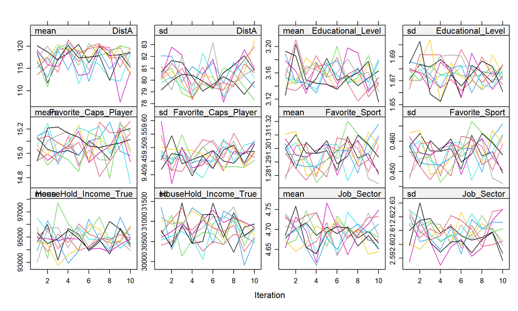

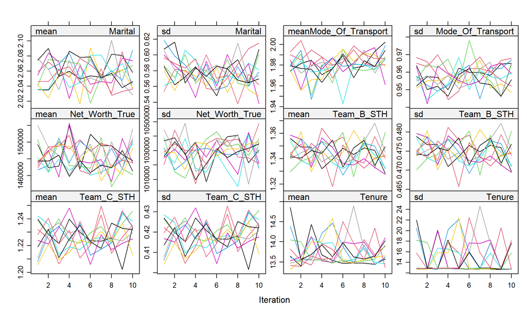

```r
# Convergence: chains should mix freely without drift
plot(mice_imp, layout=c(4,3))
```

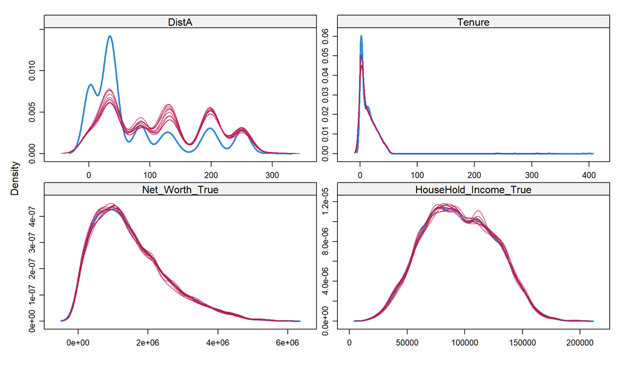

```r
# Density: blue = observed, red = imputed (should roughly overlap for numeric vars)
densityplot(mice_imp, ~ DistA + Tenure + Net_Worth_True + HouseHold_Income_True)
```

```r
# Extract completed dataset (imputation #1)
MDdf_imputed <- complete(mice_imp, 1)

remaining_na <- colSums(is.na(MDdf_imputed[, impute_with_na]))
if(sum(remaining_na) == 0) {
  cat("All", length(impute_with_na), "variables fully imputed — 0 NAs remaining.\n")
} else {
  print(remaining_na[remaining_na > 0])
}
```

```
## All 18 variables fully imputed — 0 NAs remaining.
```

```r
cat("Final dataset:", nrow(MDdf_imputed), "rows x", ncol(MDdf_imputed), "cols\n")
```

```
## Final dataset: 9447 rows x 45 cols
```

```r
tryCatch({
  write.csv(MDdf_imputed, "MDdf_imputed.csv", row.names=FALSE)
  cat("Saved to MDdf_imputed.csv\n")
}, error = function(e) cat("Note: Could not save MDdf_imputed.csv (file may be open):", conditionMessage(e), "\n"))
```

```
## Saved to MDdf_imputed.csv
```

### Summary: MD Steps 1–7

[output not shown]